# dsj_churn

```python
%load_ext autoreload
%autoreload 2
```

```python
import os
import sys

# Data Manipulation ##################################################################################################
import numpy as np
import pandas as pd

# EDA ##############################################################################################################
from ydata_profiling import ProfileReport


# Visualization ######################################################################################################
import seaborn as sns
import matplotlib.pyplot as plt
import plotly.offline as py
import plotly.graph_objs as go # visualization
from plotly.subplots import make_subplots
import plotly.figure_factory as ff # visualization


import warnings
warnings.filterwarnings('ignore')
```

```python
# Importing my custom functions to facilitate the analysis and modelling

%aimport ml_utils
import ml_utils as mu
```

```python
data = pd.read_csv('data/churn_all.csv')
data.head()
```

|  | state | area_code | phone_number | international_plan | voice_mail_plan | number_vmail_messages | total_day_minutes | total_day_calls | total_day_charge | total_eve_minutes | total_eve_calls | total_eve_charge | total_night_minutes | total_night_calls | total_night_charge | total_intl_minutes | total_intl_calls | total_intl_charge | number_customer_service_calls | Churn |
| --- | --- | --- | --- | --- | --- | --- | --- | --- | --- | --- | --- | --- | --- | --- | --- | --- | --- | --- | --- | --- |
| 0 | KS | 415 | 382-4657 | no | yes | 25 | 265.1 | 110 | 45.07 | 197.4 | 99 | 16.78 | 244.7 | 91 | 11.01 | 10.0 | 3 | 2.70 | 1 | False |
| 1 | OH | 415 | 371-7191 | no | yes | 26 | 161.6 | 123 | 27.47 | 195.5 | 103 | 16.62 | 254.4 | 103 | 11.45 | 13.7 | 3 | 3.70 | 1 | False |
| 2 | NJ | 415 | 358-1921 | no | no | 0 | 243.4 | 114 | 41.38 | 121.2 | 110 | 10.30 | 162.6 | 104 | 7.32 | 12.2 | 5 | 3.29 | 0 | False |
| 3 | OH | 408 | 375-9999 | yes | no | 0 | 299.4 | 71 | 50.90 | 61.9 | 88 | 5.26 | 196.9 | 89 | 8.86 | 6.6 | 7 | 1.78 | 2 | False |
| 4 | OK | 415 | 330-6626 | yes | no | 0 | 166.7 | 113 | 28.34 | 148.3 | 122 | 12.61 | 186.9 | 121 | 8.41 | 10.1 | 3 | 2.73 | 3 | False |

```python
mu.dataoveriew(data, 'Overiew of the dataset')
```

```
Overiew of the dataset:

Rows: 5000

Number of features: 20

Features:
['state', 'area_code', 'phone_number', 'international_plan', 'voice_mail_plan', 'number_vmail_messages', 'total_day_minutes', 'total_day_calls', 'total_day_charge', 'total_eve_minutes', 'total_eve_calls', 'total_eve_charge', 'total_night_minutes', 'total_night_calls', 'total_night_charge', 'total_in…

Missing values: 0
```

# EDA

```python
target = ['Churn']
text_cols = ['state']
str_cols = ['area_code', 'phone_number']
bool_cols = ['international_plan', 'voice_mail_plan']
num_cols = [col for col in data.columns if col not in target + str_cols + bool_cols + text_cols]

assert len(str_cols) + len(bool_cols) + len(num_cols) + len(target) + len(text_cols) == len(data.columns)
```

```python
data[num_cols].describe().T
```

|  | count | mean | std | min | 25% | 50% | 75% | max |
| --- | --- | --- | --- | --- | --- | --- | --- | --- |
| number_vmail_messages | 5000.0 | 7.755200 | 13.546393 | 0.0 | 0.000 | 0.00 | 17.00 | 52.00 |
| total_day_minutes | 5000.0 | 180.288900 | 53.894699 | 0.0 | 143.700 | 180.10 | 216.20 | 351.50 |
| total_day_calls | 5000.0 | 119.834000 | 442.739543 | 0.0 | 87.000 | 100.00 | 113.00 | 9999.00 |
| total_day_charge | 5000.0 | 30.649668 | 9.162069 | 0.0 | 24.430 | 30.62 | 36.75 | 59.76 |
| total_eve_minutes | 5000.0 | 200.636560 | 50.551309 | 0.0 | 166.375 | 201.00 | 234.10 | 363.70 |
| total_eve_calls | 5000.0 | 100.191000 | 19.826496 | 0.0 | 87.000 | 100.00 | 114.00 | 170.00 |
| total_eve_charge | 5000.0 | 17.054322 | 4.296843 | 0.0 | 14.140 | 17.09 | 19.90 | 30.91 |
| total_night_minutes | 5000.0 | 200.391620 | 50.527789 | 0.0 | 166.900 | 200.40 | 234.70 | 395.00 |
| total_night_calls | 5000.0 | 99.919200 | 19.958686 | 0.0 | 87.000 | 100.00 | 113.00 | 175.00 |
| total_night_charge | 5000.0 | 9.017732 | 2.273763 | 0.0 | 7.510 | 9.02 | 10.56 | 17.77 |
| total_intl_minutes | 5000.0 | 10.261780 | 2.761396 | 0.0 | 8.500 | 10.30 | 12.00 | 20.00 |
| total_intl_calls | 5000.0 | 4.435200 | 2.456788 | 0.0 | 3.000 | 4.00 | 6.00 | 20.00 |
| total_intl_charge | 5000.0 | 2.771196 | 0.745514 | 0.0 | 2.300 | 2.78 | 3.24 | 5.40 |
| number_customer_service_calls | 5000.0 | 1.570400 | 1.306363 | 0.0 | 1.000 | 1.00 | 2.00 | 9.00 |

```python
trace = go.Pie(labels = data[target].value_counts().keys().tolist(),
               values = data[target].value_counts().values.tolist(),
               marker = dict(colors = ['royalblue','lime'],
                             line = dict(color = "white", width =  1.3)
                            ),
               rotation = 90,
               hoverinfo = "label+value+text",
               hole = .5
              )
layout = go.Layout(dict(title = "Customer churn in data",
                        plot_bgcolor = "rgb(243,243,243)",
                        paper_bgcolor = "rgb(243,243,243)",
                       )
                  )
pie = [trace]
fig = go.Figure(data = pie, layout = layout)
py.iplot(fig)
```

[interactive chart not shown]

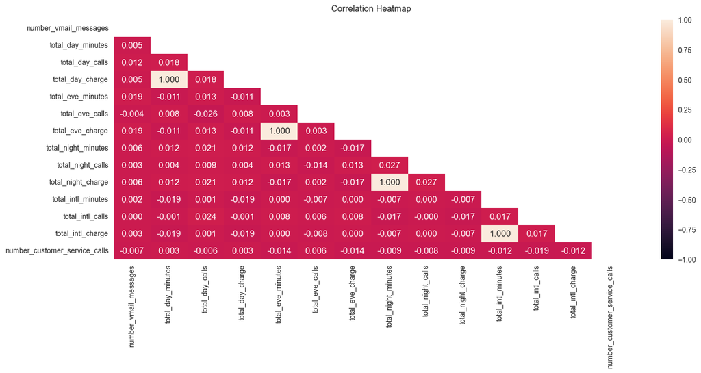

```python
corr = data[num_cols].corr()

plt.figure(figsize=(16, 6))
mask = np.triu(np.ones_like(corr, dtype=bool))
heatmap = sns.heatmap(corr, vmin=-1, vmax=1, annot=True, mask=mask, fmt='.3f')
heatmap.set_title('Correlation Heatmap', fontdict={'fontsize':12}, pad=12)
plt.grid(False);
```

Several of the numerical data are very correlated. Need to choose 1 variable from the two

- Total day minutes and Total day charge
- Total eve minutes and Total eve charge
- Total night minutes and Total night charge
- Total intl minutes and Total intl charge

```python
num_cols
```

```
['number_vmail_messages',
 'total_day_minutes',
 'total_day_calls',
 'total_day_charge',
 'total_eve_minutes',
 'total_eve_calls',
 'total_eve_charge',
 'total_night_minutes',
 'total_night_calls',
 'total_night_charge',
 'total_intl_minutes',
 'total_intl_calls',
 'total_intl_charge',
 'number_customer_service_calls']
```

```python
num_cols[0]
```

```
'number_vmail_messages'
```

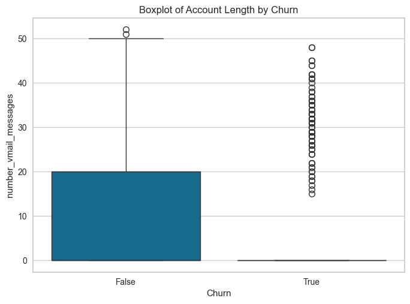

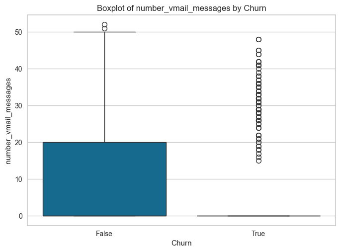

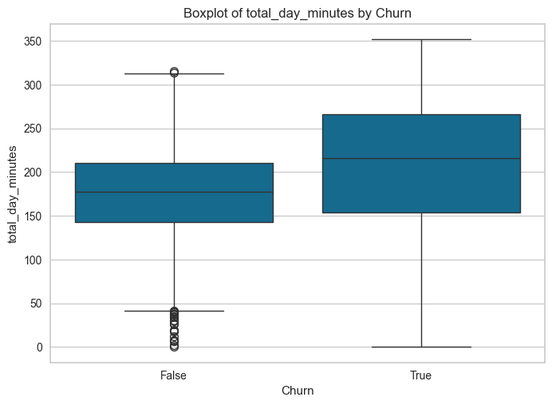

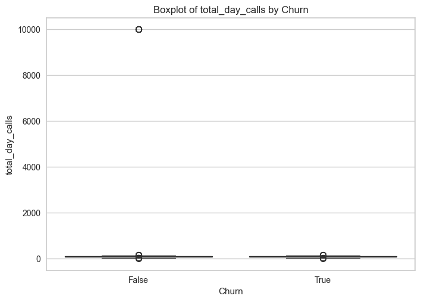

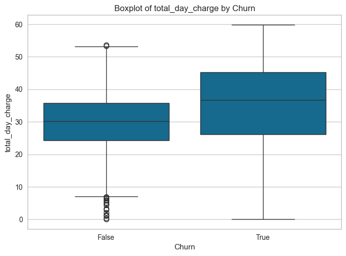

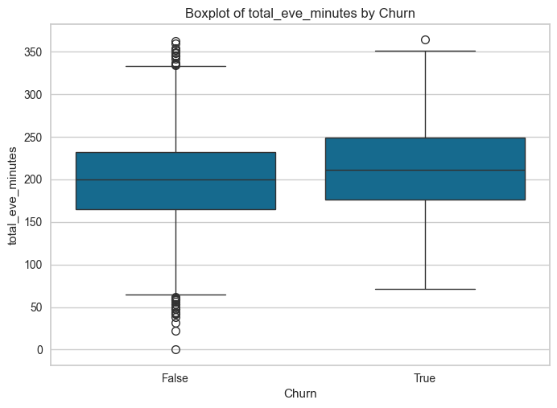

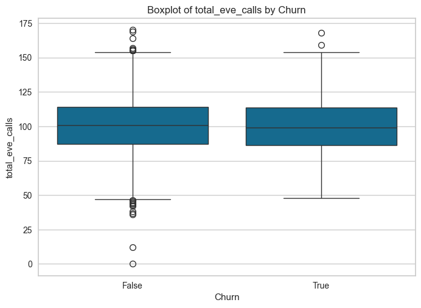

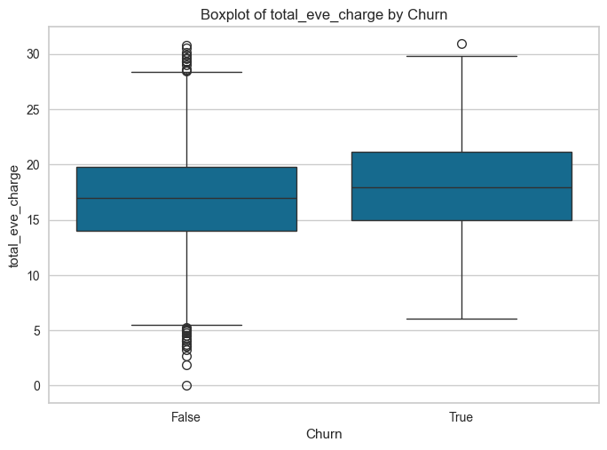

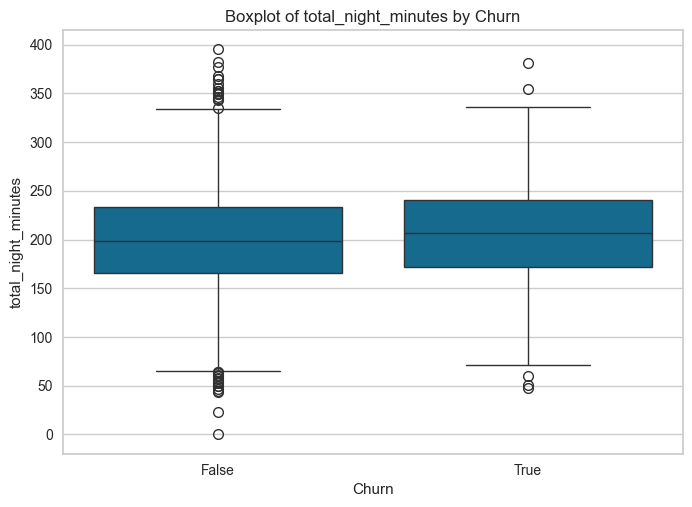

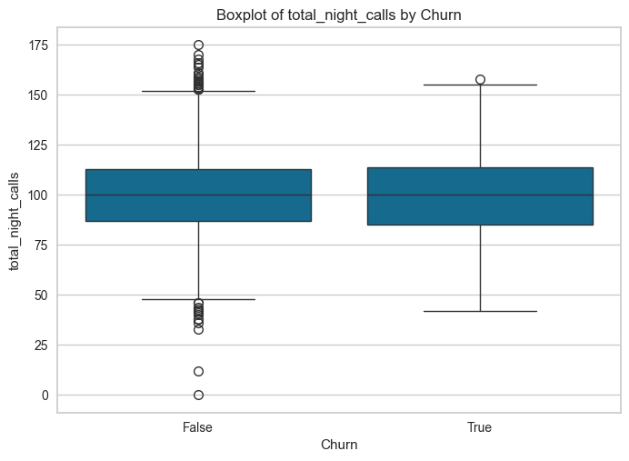

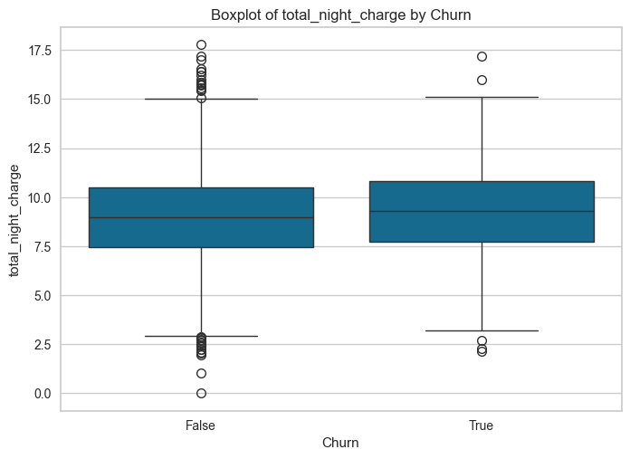

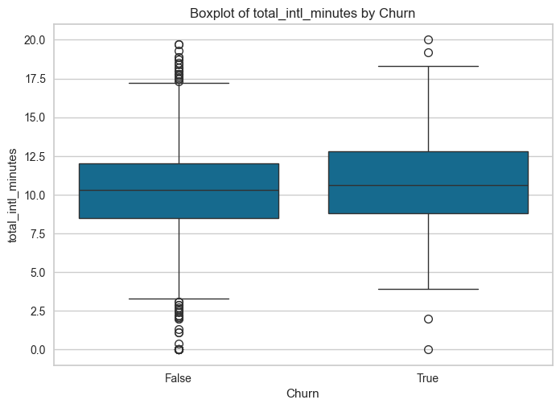

[3 more figures not shown]

```python
# target = data['Churn'].map({0: 'Not Churn', 1: 'Churn'})
sns.boxplot(x='Churn', y=num_cols[0], data=data)
plt.title('Boxplot of Account Length by Churn')
plt.show()

for col in num_cols:
    sns.boxplot(x='Churn', y=col, data=data)
    plt.title(f'Boxplot of {col} by Churn')
    plt.show()
```

Based on a quick analysis, we can see that `total_day_minutes` and `number_customer_service_calls` seem to be important predictors and since `total_day_minutes` seems to be an important predictor, let's use it to create a new variable by grouping people based on consumption

```python
# Creation of a new variable - consumption
median_total_day_minutes = data['total_day_minutes'].median()

# 2 consumption levels: 1 if total_day_minutes >= median_total_day_minutes else 0
data['consumption_level'] = data['total_day_minutes'].apply(lambda x: 1 if x >= median_total_day_minutes else 0)
```

# Data Preprocessing

```python
# Number of uinque states in the dataset
data['state'].nunique()
```

```
51
```

```python
data.columns
```

[output not shown]

```python
data['phone_number'].nunique()
```

```
5000
```

```python
data.dtypes
```

```
state                             object
area_code                          int64
phone_number                      object
international_plan                object
voice_mail_plan                   object
number_vmail_messages              int64
total_day_minutes                float64
total_day_calls                    int64
total_day_charge                 float64
total_eve_minutes                float64
total_eve_calls                    int64
total_eve_charge                 float64
total_night_minutes              float64
total_night_calls                  int64
total_night_charge               float64
total_intl_minutes               float64
total_intl_calls                   int64
total_intl_charge                float64
number_customer_service_calls      int64
Churn                               bool
dtype: object
```

```python
from sklearn.preprocessing import LabelEncoder
from sklearn.preprocessing import StandardScaler


# Encoding boolean & target columns
encoders = {}
for col in bool_cols + target:
    le = LabelEncoder()
    data[col] = le.fit_transform(data[col])
    encoders[col] = le
```

```python
# Dropped unecessary and correlated columns
model_cols = ['international_plan', 'voice_mail_plan', 'number_vmail_messages',
              'total_day_minutes', 'total_day_calls','total_eve_minutes',
              'total_eve_calls', 'total_night_minutes', 'total_night_calls',
              'total_intl_minutes','total_intl_calls', 'number_customer_service_calls', 'consumption_level']

cat_col =['area_code']
target = ['Churn']
data[cat_col] = data[cat_col].astype('category')
```

```python
from sklearn.model_selection import train_test_split
RANDOM_STATE = 42
TEST_SIZE = 0.2

# Train test split
X = data.drop(target, axis=1)
y = data[target]

X_train, X_val, y_train, y_val = train_test_split(X, y, test_size=TEST_SIZE, random_state=RANDOM_STATE)
```

```python
#Scaling Numerical columns

num_cols = [col for col in model_cols if data[col].dtype != 'O']

std = StandardScaler()
X_train[num_cols] = std.fit_transform(X_train[num_cols])
X_val[num_cols] = std.transform(X_val[num_cols])
```

# Modelling

## Baseline Model

```python
data[model_cols]
```

|  | international_plan | voice_mail_plan | number_vmail_messages | total_day_minutes | total_day_calls | total_eve_minutes | total_eve_calls | total_night_minutes | total_night_calls | total_intl_minutes | total_intl_calls | number_customer_service_calls | consumption_level |
| --- | --- | --- | --- | --- | --- | --- | --- | --- | --- | --- | --- | --- | --- |
| 0 | 0 | 1 | 25 | 265.1 | 110 | 197.4 | 99 | 244.7 | 91 | 10.0 | 3 | 1 | 1 |
| 1 | 0 | 1 | 26 | 161.6 | 123 | 195.5 | 103 | 254.4 | 103 | 13.7 | 3 | 1 | 0 |
| 2 | 0 | 0 | 0 | 243.4 | 114 | 121.2 | 110 | 162.6 | 104 | 12.2 | 5 | 0 | 1 |
| 3 | 1 | 0 | 0 | 299.4 | 71 | 61.9 | 88 | 196.9 | 89 | 6.6 | 7 | 2 | 1 |
| 4 | 1 | 0 | 0 | 166.7 | 113 | 148.3 | 122 | 186.9 | 121 | 10.1 | 3 | 3 | 0 |
| ... | ... | ... | ... | ... | ... | ... | ... | ... | ... | ... | ... | ... | ... |
| 4995 | 0 | 1 | 40 | 235.7 | 127 | 223.0 | 126 | 297.5 | 116 | 9.9 | 5 | 2 | 1 |
| 4996 | 0 | 0 | 0 | 184.2 | 90 | 256.8 | 73 | 213.6 | 113 | 14.7 | 2 | 3 | 1 |
| 4997 | 0 | 0 | 0 | 140.6 | 89 | 172.8 | 128 | 212.4 | 97 | 13.6 | 4 | 1 | 0 |
| 4998 | 0 | 0 | 0 | 188.8 | 67 | 171.7 | 92 | 224.4 | 89 | 8.5 | 6 | 0 | 1 |
| 4999 | 0 | 1 | 34 | 129.4 | 102 | 267.1 | 104 | 154.8 | 100 | 9.3 | 16 | 0 | 0 |

5000 rows × 13 columns

```python
from sklearn.linear_model import LogisticRegression

#Baseline model
logit = LogisticRegression(multi_class='ovr', n_jobs=1,
                           penalty='l2', random_state=RANDOM_STATE, solver='liblinear')

mu.churn_prediction(logit, X_train[model_cols], X_val[model_cols], y_train, y_val, "coefficients", threshold_plot=True)
```

```
Algorithm: LogisticRegression

Classification report:
               precision    recall  f1-score   support

           0       0.89      0.97      0.93       861
           1       0.63      0.27      0.37       139

    accuracy                           0.88      1000
   macro avg       0.76      0.62      0.65      1000
weighted avg       0.85      0.88      0.85      1000

Accuracy Score: 0.876
F1 Score: 0.37373737373737376
Precision Score: 0.6271186440677966
Recall Score: 0.26618705035971224
Area under curve: 0.6203176831357214
```

[interactive chart not shown]

## SMOTE with Logistic Regression

To handle with the severely imbalanced data, we carry out SMOTE which helps us oversample the minority class

```python
from imblearn.over_sampling import SMOTE

#oversampling minority class using smote
smote = SMOTE(random_state = 0)
X_smote, y_smote = smote.fit_resample(X_train[model_cols+cat_col], y_train)
X_smote = pd.DataFrame(data = X_smote, columns=X_train[model_cols+cat_col].columns)
y_smote = pd.DataFrame(data = y_smote, columns=target)

logit_smote = LogisticRegression(multi_class='ovr', n_jobs=1,
                           penalty='l2', random_state=RANDOM_STATE, solver='liblinear')

mu.churn_prediction(logit_smote, X_smote[model_cols], X_val[model_cols], y_smote, y_val, "coefficients", threshold_plot=True)
```

```
Algorithm: LogisticRegression

Classification report:
               precision    recall  f1-score   support

           0       0.96      0.78      0.86       861
           1       0.36      0.78      0.50       139

    accuracy                           0.78      1000
   macro avg       0.66      0.78      0.68      1000
weighted avg       0.87      0.78      0.81      1000

Accuracy Score: 0.778
F1 Score: 0.4954545454545455
Precision Score: 0.36212624584717606
Recall Score: 0.7841726618705036
Area under curve: 0.7805880730955306
```

[interactive chart not shown]

Other models to compare for Churn Classification

- Gaussian Naive Bayes
- KNN Classifier
- Random Forest Classifier
- Support Vector Machine
- LightGBM
- XGBoost
- BaggingClassifier

```python
from sklearn.ensemble import RandomForestClassifier, BaggingClassifier
from sklearn.svm import SVC
from sklearn.neighbors import KNeighborsClassifier
from sklearn.naive_bayes import GaussianNB
from lightgbm import LGBMClassifier
from xgboost import XGBClassifier
```

```python
gnb = GaussianNB()
bgc = BaggingClassifier(random_state=RANDOM_STATE)
xgc = XGBClassifier(base_score=0.5, booster='dart', learning_rate=0.9,
                    max_depth=7,  n_estimators=100,
                    n_jobs=1, objective='binary:logistic', random_state=RANDOM_STATE)
knn = KNeighborsClassifier(n_neighbors=7, n_jobs=1, )
rfc = RandomForestClassifier(n_estimators = 300, random_state = RANDOM_STATE,
                             max_depth = 9, criterion = "gini")
svc_rbf  = SVC(C=10.0, kernel='rbf', gamma=0.1, probability=True, random_state=RANDOM_STATE)
lgbmc = LGBMClassifier(learning_rate=0.5, max_depth=7,
                        min_child_weight=0.001, n_estimators=300,
                        n_jobs=-1, objective='binary', random_state=RANDOM_STATE,
                        verbose = -1,)

models = [gnb, bgc, xgc, knn, rfc, svc_rbf, lgbmc]
results = {}
for model in models:
    print(f'Running {model.__class__.__name__}')
    metrics = mu.model_train(model, X_smote[model_cols], X_val[model_cols], y_smote, y_val)
    results[model.__class__.__name__] = metrics

results_df = pd.DataFrame(results).T
```

```
Running GaussianNB
Running BaggingClassifier
Running XGBClassifier
Running KNeighborsClassifier
Running RandomForestClassifier
Running SVC
Running LGBMClassifier
```

```python
results_df.sort_values(by='f1', ascending=False)
```

|  | accuracy | f1 | precision | recall | ROC_AUC |
| --- | --- | --- | --- | --- | --- |
| LGBMClassifier | 0.967 | 0.875472 | 0.920635 | 0.834532 | 0.911459 |
| XGBClassifier | 0.956 | 0.838235 | 0.857143 | 0.820144 | 0.899038 |
| RandomForestClassifier | 0.939 | 0.791809 | 0.753247 | 0.834532 | 0.895199 |
| BaggingClassifier | 0.935 | 0.771930 | 0.753425 | 0.791367 | 0.874778 |
| SVC | 0.908 | 0.676056 | 0.662069 | 0.690647 | 0.816868 |
| KNeighborsClassifier | 0.825 | 0.567901 | 0.432331 | 0.827338 | 0.825980 |
| GaussianNB | 0.371 | 0.290868 | 0.172460 | 0.928058 | 0.604563 |

# Hyperparamter Tuning for the 2 Best Models

```python
import optuna
import xgboost as xgb
from sklearn.metrics import f1_score


def objective(trial):
    param = {
        'objective':'binary:logistic',
        'eval_metric': 'logloss',
        'max_depth': trial.suggest_int('max_depth', 3, 10),
        'min_child_weight': trial.suggest_int('min_child_weight', 1, 10),
        'subsample': trial.suggest_float('subsample', 0.5, 1.0),
        'colsample_bytree': trial.suggest_float('colsample_bytree', 0.5, 1.0),
        'learning_rate': trial.suggest_loguniform('learning_rate', 1e-3, 0.5),
        'num_boost_round': trial.suggest_int("num_boost_round", 100, 1000),
        'enable_categorical': True,

    }

    clf = xgb.XGBClassifier(**param, RANDOM_STATE=RANDOM_STATE)
    clf.fit(X_smote[model_cols+cat_col], y_smote)
    y_pred = clf.predict(X_val[model_cols+cat_col])
    return f1_score(y_val, y_pred)

xgb_study = optuna.create_study(direction='maximize')
xgb_study.optimize(objective, n_trials=100)

# Best trial
xgb_trial = xgb_study.best_trial
print(f'F1 score: {xgb_trial.value:.4f}')
print("Best hyperparameters: {}".format(xgb_trial.params))
```

```
[I 2024-05-16 21:10:55,574] A new study created in memory with name: no-name-2c820e8e-53a5-469e-a630-c6e6b8682cbf
```

[output not shown]

[output cut: 83 more lines]

```
F1 score: 0.8731
Best hyperparameters: {'max_depth': 5, 'min_child_weight': 1, 'subsample': 0.9083146548519512, 'colsample_bytree': 0.6374717501354991, 'learning_rate': 0.3077050114862642, 'num_boost_round': 155}
```

- Base XGB Performance:F1 score 0.8382
- Tuned XGB Performance: F1 score 0.8731

```python
import lightgbm as lgb

def objective(trial):
    param = {
        'objective': 'binary',
        'metric': 'binary_logloss',
        'verbosity': -1,
        'lambda_l1': trial.suggest_loguniform('lambda_l1', 1e-8, 10.0),
        'lambda_l2': trial.suggest_loguniform('lambda_l2', 1e-8, 10.0),
        'num_leaves': trial.suggest_int('num_leaves', 2, 256),
        'feature_fraction': trial.suggest_uniform('feature_fraction', 0.4, 1.0),
        'bagging_fraction': trial.suggest_uniform('bagging_fraction', 0.4, 1.0),
        'bagging_freq': trial.suggest_int('bagging_freq', 1, 7),
        'min_child_samples': trial.suggest_int('min_child_samples', 5, 100),
    }

    dtrain = lgb.Dataset(X_smote[model_cols], label=y_smote)
    gbm = lgb.train(param, dtrain)
    y_pred = gbm.predict(X_val[model_cols])
    pred_labels = np.rint(y_pred)

    return f1_score(y_val, pred_labels)

lgbm_study = optuna.create_study(direction='maximize')
lgbm_study.optimize(objective, n_trials=100)

# Best trial
lgbm_trial = lgbm_study.best_trial
print(f'F1 score: {lgbm_trial.value:.4f}')
print("Best hyperparameters: {}".format(lgbm_trial.params))
```

```
[I 2024-05-16 21:11:41,862] A new study created in memory with name: no-name-c3677c79-7f42-45cb-aa28-93892124bde6
```

[output not shown]

[output cut: 83 more lines]

```
F1 score: 0.8830
Best hyperparameters: {'lambda_l1': 1.0361072427805406e-06, 'lambda_l2': 1.3680024975472513e-07, 'num_leaves': 109, 'feature_fraction': 0.8843071731155083, 'bagging_fraction': 0.7527071861211397, 'bagging_freq': 2, 'min_child_samples': 8}
```

- Base LGBM Performance: F1 score: 0.8754
- Tuned LGBM Performance: F1 score: 0.8830

```python
tuned_lgbm = LGBMClassifier(**lgbm_trial.params, random_state=RANDOM_STATE, n_jobs=-1, verbose=-1)
tuned_lgbm.fit(X_smote[model_cols], y_smote)
```

```
LGBMClassifier(bagging_fraction=0.7527071861211397, bagging_freq=2,
               feature_fraction=0.8843071731155083,
               lambda_l1=1.0361072427805406e-06,
               lambda_l2=1.3680024975472513e-07, min_child_samples=8, n_jobs=-1,
               num_leaves=109, random_state=42, verbose=-1)
```

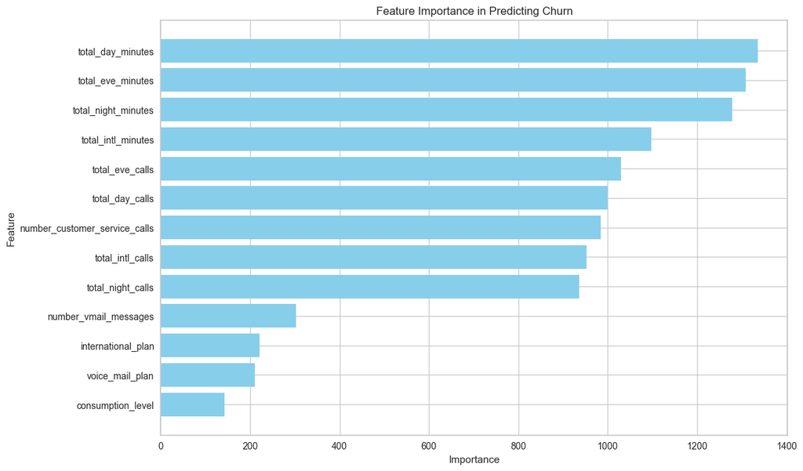

```python
# Get feature importances
feature_importances = tuned_lgbm.feature_importances_
feature_names = model_cols

# Create a DataFrame for visualization
importance_df = pd.DataFrame({
    'Feature': feature_names,
    'Importance': feature_importances
}).sort_values(by='Importance', ascending=False)


# Plot feature importances
plt.figure(figsize=(12, 8))
plt.barh(importance_df['Feature'], importance_df['Importance'], color='skyblue')
plt.xlabel('Importance')
plt.ylabel('Feature')
plt.title('Feature Importance in Predicting Churn')
plt.gca().invert_yaxis()
plt.show()
```

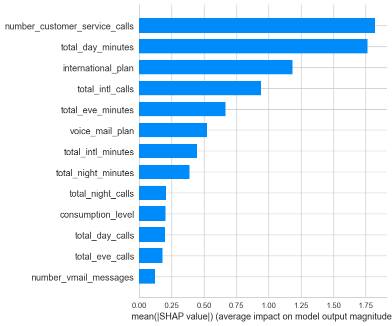

```python
# TO get the true understanding for magnitude of impact, we can use SHAP values

import shap
explainer = shap.Explainer(tuned_lgbm)
shap_values = explainer.shap_values(X_val[model_cols])

# Plot summary plot
shap.summary_plot(shap_values, X_val[model_cols], feature_names=model_cols, plot_type='bar')
```

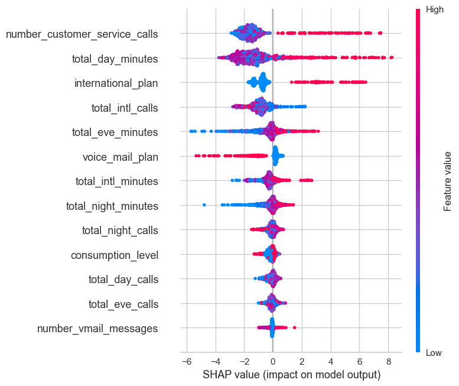

```python
# SHAP summary plot
shap.summary_plot(shap_values, X_val[model_cols])
```

As mentioned previously, in terms of explainability, it is better to use SHAP values than the feature importance given by the model. Based on the SHAP values, we can see that most influential factors are `number_customer_service_calls`, `total_day_minutes`, `international_plan`. We can also see that an increase in these 3 factors increased the probability of `Churn`. This makes sense for the following reasons:

- `number_customer_service_calls`: High value indicates customer dissatisfaction, more likely to quit
- `total_day_minutes`: High values indicate a lot of use at which point the user may not like the plan or price they are paying
- `international_plan`: If this variable is True, then the user might be travelling a lot and the specific international plan may not meet their needs.

# Final Model Building and Evaluation

- The main metrics for evaluation will be F1 score and ROC AUC score.
- F1 offers a balance between precision and recall
- ROC AUC helps understand the model's discriminative ability
- Both are well suited for imbalanced dataset.
- To validate the model, I took the best lgbm model parameters and applied it back on the original imbalanced data to test how the model performs across different folds

```python
from sklearn.model_selection import StratifiedKFold
from sklearn.metrics import f1_score, precision_score, recall_score, roc_auc_score

n_splits = 10
kf = StratifiedKFold(n_splits=n_splits, shuffle=True, random_state=RANDOM_STATE)

roc_auc_scores = []
f1_scores = []
precision_scores = []
recall_scores = []

for train_index, val_index in kf.split(X_train[model_cols], y_train):
    X_train_fold, X_val_fold = X_train[model_cols].iloc[train_index], X_train[model_cols].iloc[val_index]
    y_train_fold, y_val_fold = y_train.iloc[train_index], y_train.iloc[val_index]

    model = LGBMClassifier(**lgbm_trial.params, random_state=RANDOM_STATE, n_jobs=-1, verbose=-1)

    model.fit(X_train_fold, y_train_fold)
    y_pred = model.predict(X_val_fold)

    roc_auc_scores.append(roc_auc_score(y_val_fold, y_pred))
    f1_scores.append(f1_score(y_val_fold, y_pred))
    precision_scores.append(precision_score(y_val_fold, y_pred))
    recall_scores.append(recall_score(y_val_fold, y_pred))
```

```python
roc_auc_scores = np.array(roc_auc_scores)
f1_scores = np.array(f1_scores)
precision_scores = np.array(precision_scores)
recall_scores = np.array(recall_scores)

iterations = np.arange(1, n_splits+1)

cv_results = pd.DataFrame({'roc_auc': roc_auc_scores, 'f1': f1_scores, 'precision': precision_scores, 'recall': recall_scores}, index=iterations)
cv_results
```

|  | roc_auc | f1 | precision | recall |
| --- | --- | --- | --- | --- |
| 1 | 0.851329 | 0.800000 | 0.909091 | 0.714286 |
| 2 | 0.848422 | 0.784314 | 0.869565 | 0.714286 |
| 3 | 0.839190 | 0.795918 | 0.951220 | 0.684211 |
| 4 | 0.865506 | 0.831683 | 0.954545 | 0.736842 |
| 5 | 0.849419 | 0.816327 | 0.975610 | 0.701754 |
| 6 | 0.871362 | 0.826923 | 0.914894 | 0.754386 |
| 7 | 0.874278 | 0.843137 | 0.955556 | 0.754386 |
| 8 | 0.859675 | 0.800000 | 0.875000 | 0.736842 |
| 9 | 0.866963 | 0.840000 | 0.976744 | 0.736842 |
| 10 | 0.887448 | 0.841121 | 0.900000 | 0.789474 |

```python
print(f'Mean ROC AUC: {cv_results["roc_auc"].mean():.4f} +/- {cv_results["roc_auc"].std():.4f}')
print(f'Mean F1: {cv_results["f1"].mean():.4f} +/- {cv_results["f1"].std():.4f}')
print(f'Mean Precision: {cv_results["precision"].mean():.4f} +/- {cv_results["precision"].std():.4f}')
print(f'Mean Recall: {cv_results["recall"].mean():.4f} +/- {cv_results["recall"].std():.4f}')
```

```
Mean ROC AUC: 0.8614 +/- 0.0145
Mean F1: 0.8179 +/- 0.0216
Mean Precision: 0.9282 +/- 0.0397
Mean Recall: 0.7323 +/- 0.0302
```

# Selecting 500 customers

Assumption: Need to answer this question based on the current dataset  
Hence, I will use my trained model to identify the 500 customers suitable for this experiment

```python
# Combine training and validation data
full_data = pd.concat([X_train, X_val])
full_target = pd.concat([y_train, y_val])

# Train the model on the full data and get the probabilities as well which we can then use to choose the 500 at mosk risk of churning
full_preds = tuned_lgbm.predict(full_data[model_cols])
full_preds_proba = tuned_lgbm.predict_proba(full_data[model_cols])[:, 1]
```

```python
# Convert full_preds to pandas Series
full_preds_series = pd.Series(full_preds)
full_preds_series = full_preds_series.apply(lambda x: True if x == 1 else False)
```

```python
full_preds_series.value_counts()
```

```
False    4307
True      693
Name: count, dtype: int64
```

```python
idx = full_preds_series[full_preds_series == True].index
churn_probabilites = full_preds_proba[idx]
churn_customers = full_data.loc[idx]
churn_customers['churn_probability'] = churn_probabilites
churn_customers.sort_values(by='churn_probability', ascending=False, inplace=True)
churn_customers['phone_number'][:500]
```

```
3133     387-6065
96       370-3450
1774     335-2274
3841     379-2244
1735     368-6174
          ...
3267     417-7722
279      355-4842
1726     358-3114
2902     346-8863
2709     403-1742
Name: phone_number, Length: 500, dtype: object
```

These will be the 500 customers that I would choose for the intervention